# Rummikub — Function Reference

R tools to understand and analyze the game of Rummikub

# Overview

This project provides a set of **R functions** to analyze the board game **Rummikub**. The goal is not to build a playable game with bots, but to write code that helps us understand the rules, probabilities and strategies of the game.

The functions are organized into 8 scripts, one per objective. Every script loads the shared ones it needs with `source()`, so all of them use the same tile representation.

## Tile representation

All functions work with `data.frame`s with two columns:

- `number`: an integer in `1:13`, or `NA` for a joker.
- `colour`: one of `"red"`, `"blue"`, `"yellow"`, `"black"`, or `"wild"` for a joker.

A *meld* is a `data.frame` with these same columns. A *board* is a list of melds, or a single `data.frame` with an extra `meld_id` column.

## Repository structure

| File | Objective |
| --- | --- |
| `scripts/00_tile_pool.R` | Shared tile pool definition |
| `scripts/01_valid_melds.R` | 1: valid meld detection + rule of 30 |
| `scripts/02_draw_probability.R` | 2: probability of drawing a useful tile |
| `scripts/03_board_verifier.R` | 3: validate board combinations |
| `scripts/04_board_restructuring.R` | 4: rearrange existing combos |
| `scripts/05_board_visualization.R` | 5: board as `data.frame` / plot |
| `scripts/06_opening_analysis.R` | 6 (analysis A): opening analysis (rule of 30, Monte Carlo) |
| `scripts/07_runs_vs_groups.R` | 6 (analysis B): runs vs groups (relative frequency, heatmap) |
| `reports/function_reference.qmd` | This document |

## Setup

The following chunk loads every script (it is executed before the examples, with the working directory inside `reports/`):

```r
source("../scripts/00_tile_pool.R")
source("../scripts/01_valid_melds.R")
source("../scripts/02_draw_probability.R")
source("../scripts/03_board_verifier.R")
source("../scripts/04_board_restructuring.R")
source("../scripts/05_board_visualization.R")
source("../scripts/06_opening_analysis.R")
source("../scripts/07_runs_vs_groups.R")
```

**Note**

`source_local()` is defined in every script. It loads a shared script from `scripts/` by walking up from the working directory, so the scripts work no matter where R is started from. You normally never call it directly.

# Script 00 — Tile pool (`scripts/00_tile_pool.R`)

*Objective: a single, shared representation of the tiles used by every other script.*

## Constant `COLOURS`

The 4 standard colours of the game.

```r
COLOURS
```

```
[1] "red"    "blue"   "yellow" "black"
```

## `tile_pool()`

Builds the complete pool of **106 tiles**: 104 numbered tiles (numbers 1 to 13 in 4 colours, 2 copies of each combination) plus 2 jokers.

- **Arguments:** none.
- **Value:** a `data.frame(number, colour)` with 106 rows.

```r
pool <- tile_pool()
nrow(pool)
```

```
[1] 106
```

```r
head(pool, 3)
```

|  | number | colour |
| --- | --- | --- |
| 1 | 1 | red |
| 2 | 1 | red |
| 3 | 2 | red |

```r
table(pool$colour)
```

```
   red   blue yellow  black   wild
    26     26     26     26      2
```

## `tiles(number, colour)`

Builds a meld (a `data.frame` of tiles) from `number` and `colour` vectors. Use `NA` / `"wild"` for jokers.

- **Arguments:**
  - `number`: integer vector (use `NA` for jokers).
  - `colour`: character vector.
- **Value:** a `data.frame(number, colour)`.

```r
tiles(c(3, 4, 5), c("red", "red", "red"))
```

| number | colour |
| --- | --- |
| 3 | red |
| 4 | red |
| 5 | red |

## `is_joker(number, colour)`

Tells whether a tile is a joker (`number` is `NA` or `colour == "wild"`).

- **Arguments:** `number`, `colour`: scalar tile values.
- **Value:** `TRUE`/`FALSE`.

```r
is_joker(NA, "wild")
```

```
[1] TRUE
```

```r
is_joker(5, "red")
```

```
[1] FALSE
```

## `count_tiles(tiles)`

Builds an *inventory*: how many copies of each (number, colour) type a collection of tiles contains.

- **Arguments:** `tiles`: a `data.frame(number, colour)`.
- **Value:** a `data.frame(number, colour, n)` with one row per present type.

```r
count_tiles(tiles(c(5, 5, 5), c("red", "red", "blue")))
```

| number | colour | n |
| --- | --- | --- |
| 5 | blue | 1 |
| 5 | red | 2 |

## `subtract_tiles(counter, subtract)`

Subtracts one inventory from another. Used to remove the tiles we can see (hand + board) from the pool.

- **Arguments:**
  - `counter`: the inventory to subtract from.
  - `subtract`: the inventory to subtract.
- **Value:** the resulting inventory (rows with `n > 0` only).
- **Errors:** if a tile is not found, or if more copies are subtracted than exist.

```r
after <- subtract_tiles(count_tiles(tile_pool()), count_tiles(tiles(5, "red")))
sum(after$n)   # 106 - 1 = 105 tiles left
```

```
[1] 105
```

# Script 01 — Valid melds (`scripts/01_valid_melds.R`)

*Objective 1: identify valid* runs* and *groups*, compute their points and apply the opening rule of 30.*

## `is_run(meld)`

Is the meld a valid **run**? A run needs 3 or more consecutive tiles of the same colour; jokers substitute for the missing numbers.

- **Arguments:** `meld`: a `data.frame(number, colour)`.
- **Value:** `TRUE`/`FALSE`.

```r
is_run(tiles(c(3, 4, 5), c("blue", "blue", "blue")))
```

```
[1] TRUE
```

```r
is_run(tiles(c(3, 4, 5), c("blue", "blue", "red")))   # different colours
```

```
[1] FALSE
```

```r
is_run(tiles(c(3, 5, 7), c("blue", "blue", "blue")))   # gaps
```

```
[1] FALSE
```

## `assign_run(meld)`

Resolves the jokers of a valid run to their canonical numbers: first the internal gaps are filled, then the run is extended to the right.

- **Arguments:** `meld`: a valid run.
- **Value:** the resolved `data.frame(number, colour)`.
- **Errors:** if `meld` is not a valid run.

```r
assign_run(tiles(c(5, NA, NA), c("blue", "wild", "wild")))  # -> 5,6,7
```

| number | colour |
| --- | --- |
| 5 | blue |
| 6 | blue |
| 7 | blue |

## `is_group(meld)`

Is the meld a valid **group**? A group needs 3 or 4 tiles with the same number in different colours; jokers substitute for the missing colours.

- **Arguments:** `meld`: a `data.frame(number, colour)`.
- **Value:** `TRUE`/`FALSE`.

```r
is_group(tiles(c(7, 7, 7), c("red", "blue", "black")))
```

```
[1] TRUE
```

```r
is_group(tiles(c(7, 7, 7), c("red", "red", "blue")))   # repeated colour
```

```
[1] FALSE
```

## `assign_group(meld)`

Resolves the jokers of a valid group to their canonical colours (the free colours in the standard order).

- **Arguments:** `meld`: a valid group.
- **Value:** the resolved `data.frame(number, colour)`.
- **Errors:** if `meld` is not a valid group.

```r
assign_group(tiles(c(7, 7, NA), c("red", "blue", "wild")))
```

| number | colour |
| --- | --- |
| 7 | red |
| 7 | blue |
| 7 | yellow |

## `is_valid_meld(meld)`

Is the meld a valid run or a valid group?

- **Arguments:** `meld`: a `data.frame(number, colour)`.
- **Value:** `TRUE`/`FALSE`.

```r
is_valid_meld(tiles(c(9, 10, 11), c("red", "red", "red")))
```

```
[1] TRUE
```

```r
is_valid_meld(tiles(c(2, 4, 6), c("red", "red", "red")))
```

```
[1] FALSE
```

## `meld_score(meld)`

Points of a valid meld, using the canonical resolution of jokers (a joker counts as the tile it represents).

- **Arguments:** `meld`: a valid meld.
- **Value:** an integer with the point total.
- **Errors:** if `meld` is not valid.

```r
meld_score(tiles(c(9, 10, 11), c("red", "red", "red")))   # 30
```

```
[1] 30
```

```r
meld_score(tiles(c(5, 5, 5), c("red", "blue", "yellow"))) # 15
```

```
[1] 15
```

## `meets_rule_30(melds)`

Applies the **opening rule**: one or more melds whose points add up to at least 30.

- **Arguments:** `melds`: a single meld or a list of melds.
- **Value:** `TRUE`/`FALSE`.

```r
meets_rule_30(list(
  tiles(c(8, 9, 10), c("blue", "blue", "blue")),     # 27
  tiles(c(4, 4, 4), c("red", "blue", "yellow"))      # 12
))                                                    # 27 + 12 = 39
```

```
[1] TRUE
```

# Script 02 — Drawing probability (`scripts/02_draw_probability.R`)

*Objective 2: probability of drawing a useful tile from the pool.*

Context: we know our hand and the tiles visible on the board; the opponent has drawn `n_opponent` unknown tiles. Drawing is modelled as **sampling without replacement**. For a single draw, the probability does not depend on `n_opponent` (the drawn tile is uniform over the available pool).

## `available_pool(hand, board, n_opponent)`

Inventory of the tiles still available: the complete pool minus the hand and the board.

- **Arguments:**
  - `hand`, `board`: `data.frame(number, colour)` or `NULL`.
  - `n_opponent`: number of unknown tiles held by the opponent.
- **Value:** an inventory `data.frame(number, colour, n)` with attribute `total_available` (tiles left after also removing the opponent’s).
- **Errors:** if `n_opponent` is negative or larger than the pool.

```r
pool <- available_pool(hand = tiles(5, "red"))
sum(pool$n)                                        # 105 tiles left
```

```
[1] 105
```

```r
attr(pool, "total_available")                      # 95 with 10 opponent tiles
```

```
[1] 105
```

```r
available_pool(hand = tiles(5, "red"), n_opponent = 10) |>
  attr("total_available")
```

```
[1] 95
```

## `is_useful_tile(tile, hand)`

Default “useful” criterion. A tile is useful if it improves the hand:

- a joker is always useful;
- it matches the number of a hand tile with a different colour (group);
- it matches the colour of a hand tile and is a consecutive number (±1) (run).
- **Arguments:**
  - `tile`: a 1-row `data.frame(number, colour)`.
  - `hand`: the `data.frame(number, colour)` of the hand.
- **Value:** `TRUE`/`FALSE`.

```r
is_useful_tile(tiles(6, "red"), tiles(5, "red"))   # consecutive run tile
```

```
[1] TRUE
```

```r
is_useful_tile(tiles(9, "black"), tiles(5, "red")) # unrelated
```

```
[1] FALSE
```

## `useful_tiles(hand, board, n_opponent, is_useful)`

Inventory of the available tile types considered useful.

- **Arguments:** same as `available_pool()`, plus `is_useful`: the criterion (defaults to `is_useful_tile`).
- **Value:** an inventory `data.frame(number, colour, n)`.

```r
useful_tiles(tiles(5, "red"))
```

|  | number | colour | n |
| --- | --- | --- | --- |
| 31 | 4 | red | 2 |
| 33 | 5 | black | 2 |
| 34 | 5 | blue | 2 |
| 36 | 5 | yellow | 2 |
| 39 | 6 | red | 2 |
| 53 | NA | wild | 2 |

## `prob_draw_useful(hand, board, n_opponent, is_useful)`

Probability that the next drawn tile is useful = useful copies / available copies.

- **Arguments:** same as `useful_tiles()`.
- **Value:** a probability in `[0, 1]`, or `NA` if there are no tiles left.

```r
prob_draw_useful(tiles(5, "red"))   # 12 / 105
```

```
[1] 0.1142857
```

# Script 03 — Board verifier (`scripts/03_board_verifier.R`)

*Objective 3: check that a board only contains valid combinations.*

A board is a list of melds, or a `data.frame` with a `meld_id` column. `verify_board()` checks that (1) every meld is a valid run or group, and (2) the tiles are physically possible (no more copies than exist in the pool, no non-existent tiles such as a 14).

## `board_to_list(board)`

Normalizes a board to a list of melds.

- **Arguments:** `board`: a list of melds, or a `data.frame` with `meld_id`.
- **Value:** a list of `data.frame(number, colour)`.
- **Errors:** if the input format is invalid.

```r
board <- list(
  tiles(c(3, 4, 5), c("red", "red", "red")),
  tiles(c(7, 7, 7), c("blue", "yellow", "black"))
)
board_to_list(board_to_dataframe(board))   # round trip
```

```
[[1]]
  number colour
1      3    red
2      4    red
3      5    red

[[2]]
  number colour
1      7   blue
2      7 yellow
3      7  black
```

## `board_to_dataframe(melds)`

Converts a list of melds to a single `data.frame` with a `meld_id` column.

- **Arguments:** `melds`: a list of melds.
- **Value:** a `data.frame(meld_id, number, colour)`.

```r
board_to_dataframe(board)
```

| meld_id | number | colour |
| --- | --- | --- |
| 1 | 3 | red |
| 1 | 4 | red |
| 1 | 5 | red |
| 2 | 7 | blue |
| 2 | 7 | yellow |
| 2 | 7 | black |

## `check_physical(board_tiles)`

Checks that the given tiles could physically exist in the pool.

- **Arguments:** `board_tiles`: a `data.frame(number, colour)` with all the tiles on the board.
- **Value:** `list(ok, problems)`: `ok` is `TRUE`/`FALSE` and `problems` is a character vector of messages.

```r
check_physical(tiles(c(12, 13, 14), c("red", "red", "red")))
```

```
$ok
[1] FALSE

$problems
[1] "Tile 14 red appears 1 times (max 0 in the pool)"
```

## `verify_board(board, details)`

Checks the whole board.

- **Arguments:**
  - `board`: a list of melds or a `data.frame` with `meld_id`.
  - `details`: if `TRUE`, return the list below instead of `TRUE`/`FALSE`.
- **Value:** `TRUE`/`FALSE`, or `list(valid, problems)` with `details = TRUE`.

```r
verify_board(board)
```

```
[1] TRUE
```

```r
verify_board(list(tiles(c(2, 4, 6), c("red", "red", "red"))), details = TRUE)
```

```
$valid
[1] FALSE

$problems
[1] "Meld 1 is not a valid combination"
```

# Script 04 — Board restructuring (`scripts/04_board_restructuring.R`)

*Objective 4: find legal ways to place tiles from the hand by adding to, rearranging or splitting the melds already on the table.*

In Rummikub, on later turns you may break and rearrange the combos on the table as long as everything remains valid at the end of the turn. Each move is validated with `verify_board()`. Every move is a list with:

- `$board`: the resulting board (list of melds);
- `$hand`: the resulting hand;
- `$desc`: a readable description.

## `tile_label(tile)`

Human-readable label of a tile.

- **Arguments:** `tile`: a 1-row `data.frame(number, colour)`.
- **Value:** `"J"` for a joker, otherwise `"<number> <colour>"`.

```r
tile_label(tiles(NA, "wild"))
```

```
[1] "J"
```

```r
tile_label(tiles(5, "red"))
```

```
[1] "5 red"
```

## `meld_type(meld)`

- **Arguments:** `meld`: a `data.frame(number, colour)`.
- **Value:** `"run"`, `"group"`, or `"invalid"`.

```r
meld_type(tiles(c(3, 4, 5), c("red", "red", "red")))
```

```
[1] "run"
```

```r
meld_type(tiles(c(3, 4), c("red", "red")))
```

```
[1] "invalid"
```

## `resolved_meld(meld)`

The meld with its jokers resolved to their canonical values.

- **Arguments:** `meld`: a meld.
- **Value:** the resolved `data.frame`, or `NULL` if the meld is invalid.

## `move(board, hand, desc)`

Helper that builds a move list.

- **Arguments:** `board`, `hand`, `desc` (description string).
- **Value:** `list(board, hand, desc)`.

## `replace_meld(board, m, new_melds)`

Replaces meld `m` of `board` with one or more new melds.

- **Arguments:** `board`: a list of melds; `m`: the meld index; `new_melds`: a list of replacement melds.
- **Value:** the updated board.

## `add_to_meld(meld, tile)`

Tries to place a single tile on an existing meld: extend a run at its ends, fill a free colour of a group, or use a joker.

- **Arguments:** `meld`: a meld; `tile`: a 1-row `data.frame`.
- **Value:** the resulting meld if valid, or `NULL` if it cannot be done.

```r
add_to_meld(tiles(c(3, 4, 5), c("red", "red", "red")), tiles(6, "red"))
```

| number | colour |
| --- | --- |
| 3 | red |
| 4 | red |
| 5 | red |
| 6 | red |

```r
add_to_meld(tiles(c(3, 4, 5), c("red", "red", "red")), tiles(9, "red"))  # gap
```

[output not shown]

## `move_add_tile(board, hand)`

Moves that place one tile from the hand on an existing meld.

- **Arguments:** `board`, `hand`.
- **Value:** a list of moves.

```r
moves <- move_add_tile(list(tiles(c(3, 4, 5), c("red", "red", "red"))),
                       tiles(c(2, 6), c("red", "red")))
vapply(moves, function(x) x$desc, character(1))
```

```
[1] "Add 2 red to meld 1" "Add 6 red to meld 1"
```

## `move_swap_joker(board, hand)`

Replaces a joker on the table with a real tile from the hand and moves the freed joker to another meld. A joker never returns to the hand.

- **Arguments:** `board`, `hand`.
- **Value:** a list of moves.

## `movable_tiles(meld)`

Indices of the tiles that can be removed from a meld leaving a valid meld.

- **Arguments:** `meld`: a meld.
- **Value:** an integer vector of row indices.

```r
movable_tiles(tiles(c(3, 4, 5, 6), c("red", "red", "red", "red")))
```

```
[1] 1 4
```

## `move_transfer_tile(board, hand)`

Moves that transfer a tile from one meld to another (both remain valid). Does not place tiles from the hand; it prepares the ground for other moves.

- **Arguments:** `board`, `hand`.
- **Value:** a list of moves.

## `split_run(meld)`

All the ways to split a joker-free run into two valid runs of at least 3 tiles.

- **Arguments:** `meld`: a run.
- **Value:** a list of splits, each with `part1`, `part2` and `split_at`.

```r
str(split_run(tiles(2:7, rep("red", 6))))
```

```
List of 1
 $ :List of 3
  ..$ part1   :'data.frame':    3 obs. of  2 variables:
  .. ..$ number: int [1:3] 2 3 4
  .. ..$ colour: chr [1:3] "red" "red" "red"
  ..$ part2   :'data.frame':    3 obs. of  2 variables:
  .. ..$ number: int [1:3] 5 6 7
  .. ..$ colour: chr [1:3] "red" "red" "red"
  ..$ split_at: int 4
```

## `move_split_and_add(board, hand)`

Moves that split a run into two valid runs and add a tile from the hand to one of the parts.

- **Arguments:** `board`, `hand`.
- **Value:** a list of moves.

```r
moves <- move_split_and_add(list(tiles(2:7, rep("red", 6))), tiles(8, "red"))
vapply(moves, function(x) x$desc, character(1))
```

```
[1] "Split meld 1 after 4 and add 8 red to part2"
```

## `find_moves(board, hand)`

Collects **all** the moves above (add, swap joker, transfer, split & add) and returns them deduplicated by description.

- **Arguments:** `board` (list of melds or `data.frame` with `meld_id`), `hand`.
- **Value:** a list of moves.

```r
moves <- find_moves(
  list(tiles(c(3, 4, 5), c("red", "red", "red"))),
  tiles(c(2, 6), c("red", "red"))
)
vapply(moves, function(x) x$desc, character(1))
```

```
[1] "Add 2 red to meld 1" "Add 6 red to meld 1"
```

## `move_descriptions(board, hand)`

Just the descriptions of `find_moves()` (convenient for debugging).

- **Arguments:** `board`, `hand`.
- **Value:** a character vector.

```r
move_descriptions(list(tiles(c(3, 4, 5), c("red", "red", "red"))), tiles(6, "red"))
```

```
[1] "Add 6 red to meld 1"
```

# Script 05 — Board visualization (`scripts/05_board_visualization.R`)

*Objective 5: represent the board state as a tidy `data.frame` or a plot.*

## `order_meld(meld)`

Orders the tiles of a meld: runs by number (jokers last), groups by the standard colour order.

- **Arguments:** `meld`: a meld.
- **Value:** the ordered `data.frame(number, colour)`.

```r
order_meld(tiles(c(5, 3, 4), c("red", "red", "red")))
```

|  | number | colour |
| --- | --- | --- |
| 2 | 3 | red |
| 3 | 4 | red |
| 1 | 5 | red |

## `board_to_data(board)`

Board as a tidy `data.frame` with one row per tile.

- **Arguments:** `board`: a list of melds or a `data.frame` with `meld_id`.
- **Value:** `data.frame(meld, position, number, colour, label)`, where `label` is the number or `"J"` for a joker.

```r
board_to_data(board)
```

| meld | position | number | colour | label |
| --- | --- | --- | --- | --- |
| 1 | 1 | 3 | red | 3 |
| 1 | 2 | 4 | red | 4 |
| 1 | 3 | 5 | red | 5 |
| 2 | 1 | 7 | blue | 7 |
| 2 | 2 | 7 | yellow | 7 |
| 2 | 3 | 7 | black | 7 |

## `show_board(board)`

Prints a readable description of the board to the console.

- **Arguments:** `board`.
- **Value:** `invisible(NULL)`.

```r
show_board(board)
```

```
Meld 1 (run): 3 red | 4 red | 5 red
Meld 2 (group): 7 blue | 7 yellow | 7 black
```

## `plot_board(board, title)`

Plots the board with **ggplot2**: one cell per tile, coloured by colour and labelled on top.

- **Arguments:** `board`; `title`: plot title.
- **Value:** a `ggplot` object (requires `ggplot2`).

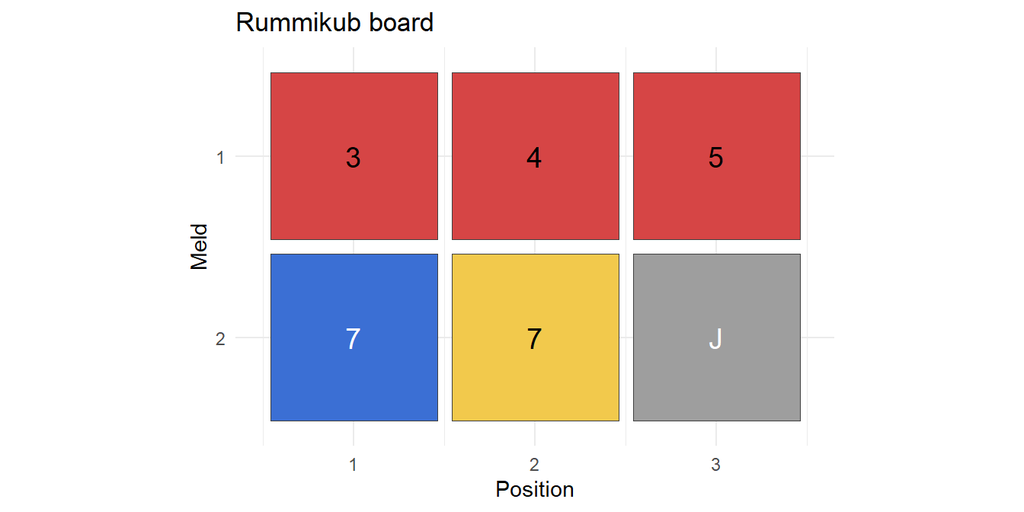

```r
if (requireNamespace("ggplot2", quietly = TRUE)) {
  plot_board(list(
    tiles(c(3, 4, 5), c("red", "red", "red")),
    tiles(c(7, 7, NA), c("blue", "yellow", "wild"))
  ))
}
```

# Script 06 — Opening analysis (`scripts/06_opening_analysis.R`)

*Objective 6, analysis A: the opening (rule of 30).*

Questions answered: (1) with what probability can you open using only the 14 initial tiles? (2) how many draws are needed on average to open when the initial hand cannot reach 30?

The methods are **exact** (a branch-and-bound solver enumerates disjoint melds) wrapped in a **Monte Carlo** simulation.

## `random_hand(k)`

- **Arguments:** `k`: number of tiles (default 14).
- **Value:** `k` random tiles from the pool, without replacement.

```r
random_hand(5)
```

|  | number | colour |
| --- | --- | --- |
| 41 | 8 | blue |
| 14 | 7 | red |
| 52 | 13 | blue |
| 70 | 9 | yellow |
| 101 | 12 | black |

## `prepare_hand(hand)`

Compact representation of a hand as counters per tile type.

- **Arguments:** `hand`: a `data.frame(number, colour)`.
- **Value:** `list(types, joker_idx)`:
  - `types`: `data.frame(number, colour, n, value)` with one row per present type (`value` is the tile number, `13` as an upper bound for jokers);
  - `joker_idx`: index of the joker row (`integer(0)` if none).

```r
prep <- prepare_hand(tiles(c(4, 5, 6, 6, 6), c("red", "red", "red", "blue", "yellow")))
prep$types
```

| number | colour | n | value |
| --- | --- | --- | --- |
| 4 | red | 1 | 4 |
| 5 | red | 1 | 5 |
| 6 | red | 1 | 6 |
| 6 | blue | 1 | 6 |
| 6 | yellow | 1 | 6 |

## `possible_melds(prep)`

Enumerates all melds (runs and groups, jokers included) formable with the hand.

- **Arguments:** `prep`: the output of `prepare_hand()`.
- **Value:** `list(M, sums, type)`:
  - `M`: matrix (melds × types) with the tiles each meld uses;
  - `sums`: the point total of each meld;
  - `type`: `"run"` or `"group"` for each meld (a meld made of a single real tile plus jokers could be either, so the type is tagged at generation).

```r
melds <- possible_melds(prep)
nrow(melds$M)          # number of formable melds
```

```
[1] 2
```

```r
head(melds$sums, 8)    # their points
```

```
[1] 15 18
```

## `solve_opening(hand, target)`

- **Arguments:** `hand`; `target`: with a finite value the search stops as soon as it is reached (ideal for the rule of 30); with `Inf` it computes the exact maximum.
- **Value:** an integer score (0 if no meld can be formed).

```r
solve_opening(tiles(c(4, 5, 6, 4, 5, 6, NA),
                    c(rep("red", 3), rep("blue", 3), "wild")))
```

```
[1] 33
```

## `can_open(hand)`

Can the hand open under the rule of 30?

- **Arguments:** `hand`.
- **Value:** `TRUE`/`FALSE`.

```r
can_open(tiles(c(9, 10, 11, NA), c("red", "red", "red", "wild")))
```

```
[1] TRUE
```

## `max_opening(hand)`

Exact maximum opening score (for the score distribution).

- **Arguments:** `hand`.
- **Value:** an integer.

```r
max_opening(tiles(c(3, 4, 5, 6, 7), rep("red", 5)))   # 3+4+5+6+7 = 25
```

```
[1] 25
```

## `solve_opening_coverage(hand)`

Maximum number of tiles coverable with **disjoint** melds of the hand (coverage version of `solve_opening()`). Used by analysis B to decide which melds can actually be played together.

- **Arguments:** `hand`.
- **Value:** an integer (0 if no meld can be formed).

```r
solve_opening_coverage(tiles(c(3, 4, 5, 6, 3, 3),
                             c("red", "red", "red", "red", "blue", "black")))
```

```
[1] 6
```

```r
# run 4-5-6 + group of 3s cover 6 tiles (more than the run 3-4-5-6 alone)
```

## `simulate_draws_until_open()`

Draws tiles one at a time from the pool until the hand can open.

- **Arguments:** none.
- **Value:** the number of draws needed (0 if the 14 initial tiles already open).

```r
set.seed(1)
simulate_draws_until_open()
```

```
[1] 9
```

## Running the analysis

When launched directly (`Rscript scripts/06_opening_analysis.R`), the script runs 5,000 random hands plus 5,000 draw simulations, prints a summary to the console and saves the results in `results/`:

- `opening_probability.csv` — probability of opening with the 14 initial tiles (with 95% confidence interval).
- `opening_max_score.csv` — maximum opening score per hand.
- `opening_draws.csv` — draws needed per simulated game.
- `opening_draws_distribution.csv` — distribution of draws.
- `opening_draws_summary.csv` — summary statistics.
- `opening_score_histogram.png` — histogram of the maximum score.
- `opening_cumulative_probability.png` — cumulative probability of having opened after `t` draws.

# Script 07 — Runs vs groups (`scripts/07_runs_vs_groups.R`)

*Objective 6, analysis B: relative frequency of runs and groups in random hands, and a heatmap of melds by tile number.*

## `tally_hand_melds(prep)`

Tallies the optimal disjoint play of one prepared hand.

- **Arguments:** `prep`: the output of `prepare_hand()`.
- **Value:** a list with `covered` (tiles used), `n_runs`, `n_groups` and the heat vectors `heat_run` / `heat_group` (integer(13): number of played melds of each type that use each tile number).

```r
tally_hand_melds(prepare_hand(tiles(c(3, 4, 5, 6, 3, 3),
                                    c("red", "red", "red", "red", "blue", "black"))))
```

```
$covered
[1] 6

$n_runs
[1] 1

$n_groups
[1] 1

$heat_run
 [1] 0 0 0 1 1 1 0 0 0 0 0 0 0

$heat_group
 [1] 0 0 1 0 0 0 0 0 0 0 0 0 0
```

## `tally_runs_groups(n_hands, k, seed)`

Monte Carlo tally over random hands.

- **Arguments:** `n_hands`: number of hands (default 10000); `k`: tiles per hand (default 14); `seed`: optional seed for reproducibility.
- **Value:** a list with:
  - `per_hand`: `data.frame(n_runs, n_groups, covered)` with one row per hand;
  - `heat`: `data.frame(number, run, group)` with the total number of played melds of each type that use each tile number (1 to 13);
  - `n_hands`, `k`: the parameters used.

```r
set.seed(1)
res <- tally_runs_groups(50L)
sum(res$per_hand$n_runs)   # total runs played
```

```
[1] 38
```

```r
head(res$heat, 4)
```

|  | number | run | group |
| --- | --- | --- | --- |
| 1 | 1 | 2 | 1 |
| 2 | 2 | 4 | 1 |
| 3 | 3 | 7 | 3 |
| 4 | 4 | 13 | 3 |

## Running the analysis

When launched directly (`Rscript scripts/07_runs_vs_groups.R`), the script runs 10,000 random hands, prints a summary to the console and saves the results in `results/`:

- `runs_vs_groups_per_hand.csv` — runs, groups and covered tiles per hand.
- `runs_vs_groups_summary.csv` — aggregate statistics (relative frequency, mean melds and mean covered tiles per hand, dominance of each type).
- `runs_vs_groups_heatmap.csv` — played melds by tile number and type (total and mean per hand).
- `runs_vs_groups_distribution.png` — histogram of played melds per hand by type.
- `runs_vs_groups_heatmap.png` — heatmap of played melds by tile number and type.

# Summary table

| Script | Key functions |
| --- | --- |
| `00_tile_pool.R` | `tile_pool()`, `tiles()`, `is_joker()`, `count_tiles()`, `subtract_tiles()` |
| `01_valid_melds.R` | `is_run()`, `is_group()`, `assign_run()`, `assign_group()`, `is_valid_meld()`, `meld_score()`, `meets_rule_30()` |
| `02_draw_probability.R` | `available_pool()`, `is_useful_tile()`, `useful_tiles()`, `prob_draw_useful()` |
| `03_board_verifier.R` | `board_to_list()`, `board_to_dataframe()`, `check_physical()`, `verify_board()` |
| `04_board_restructuring.R` | `add_to_meld()`, `move_add_tile()`, `move_swap_joker()`, `move_transfer_tile()`, `move_split_and_add()`, `find_moves()`, `move_descriptions()` |
| `05_board_visualization.R` | `order_meld()`, `board_to_data()`, `show_board()`, `plot_board()` |
| `06_opening_analysis.R` | `random_hand()`, `prepare_hand()`, `possible_melds()`, `solve_opening()`, `can_open()`, `max_opening()`, `solve_opening_coverage()`, `simulate_draws_until_open()` |
| `07_runs_vs_groups.R` | `tally_hand_melds()`, `tally_runs_groups()` |

Rendered from `reports/function_reference.qmd` with Quarto.